# Preparación y Exploración de los Datos

## Introducción

Dado al aumento de las tasas de incumplimiento de los clientes, Credit One como ente encargado de aprobar los préstamos a los clientes en primer lugar, ve comprometida su credibilidad en el servicio brindado. Por ello, con el objetivo de conservar los clientes, Credit One desea implementar una solución que permita determinar con certeza si el cliente en estudio va a poder efectuar o no los pagos del préstamo. Para comenzar con la solución al problema planteado, la empresa ha facilitado un conjunto de datos para su estudio y análisis.

En el presente documento se muestra un exploración completa de los datos de Credit One; determinando aquellos atribudos del conjunto de datos que se consideran estadísticamente significativos para la interrogante y poder, de este modo, extraer información concreta de los datos que nos acerquen a una posible solución al problema planteado. El análisis de los datos se realiza por medio de Python y el uso de librerías como Numpy, Pandas y Matplotlib.

## Importación y Preparación de los Datos

Dado que se está haciendo uso de Python, se emplea la librería Pandas. Para poder acceder a las diferentes funciones y métodos que permite dicha librería, es necario llamarla de la siguiente manera:

```python
import pandas as pd
```

Ahora, cada vez que se requiera funciones o métodos dentro de la libreria Pandas solo es necesario usar 'pd' para hacer referencia a la misma.

Seguidamente, se importan los datos a analizar por medio de la libreria Pandas ejecutando la función read_csv(), tal y como se muestra a continuación:

```python
credit = pd.read_csv('default of credit card clients.csv', header = 1)
```

Se puede ver una muestra rápida de los datos mediante la función head() y llamando al marco de datos previamente cargado.

```python
credit.head()
```

|  | ID | LIMIT_BAL | SEX | EDUCATION | MARRIAGE | AGE | PAY_0 | PAY_2 | PAY_3 | PAY_4 | ... | BILL_AMT4 | BILL_AMT5 | BILL_AMT6 | PAY_AMT1 | PAY_AMT2 | PAY_AMT3 | PAY_AMT4 | PAY_AMT5 | PAY_AMT6 | default payment next month |
| --- | --- | --- | --- | --- | --- | --- | --- | --- | --- | --- | --- | --- | --- | --- | --- | --- | --- | --- | --- | --- | --- |
| 0 | 1 | 20000 | 2 | 2 | 1 | 24 | 2 | 2 | -1 | -1 | ... | 0 | 0 | 0 | 0 | 689 | 0 | 0 | 0 | 0 | 1 |
| 1 | 2 | 120000 | 2 | 2 | 2 | 26 | -1 | 2 | 0 | 0 | ... | 3272 | 3455 | 3261 | 0 | 1000 | 1000 | 1000 | 0 | 2000 | 1 |
| 2 | 3 | 90000 | 2 | 2 | 2 | 34 | 0 | 0 | 0 | 0 | ... | 14331 | 14948 | 15549 | 1518 | 1500 | 1000 | 1000 | 1000 | 5000 | 0 |
| 3 | 4 | 50000 | 2 | 2 | 1 | 37 | 0 | 0 | 0 | 0 | ... | 28314 | 28959 | 29547 | 2000 | 2019 | 1200 | 1100 | 1069 | 1000 | 0 |
| 4 | 5 | 50000 | 1 | 2 | 1 | 57 | -1 | 0 | -1 | 0 | ... | 20940 | 19146 | 19131 | 2000 | 36681 | 10000 | 9000 | 689 | 679 | 0 |

5 rows × 25 columns

El siguiente punto de negocio es comprender la composión de los datos. Al hacer uso de Pandas, es posible obtenerlo mediante la función describe() de la siguiente manera:

```python
credit.describe()
```

|  | ID | LIMIT_BAL | SEX | EDUCATION | MARRIAGE | AGE | PAY_0 | PAY_2 | PAY_3 | PAY_4 | ... | BILL_AMT4 | BILL_AMT5 | BILL_AMT6 | PAY_AMT1 | PAY_AMT2 | PAY_AMT3 | PAY_AMT4 | PAY_AMT5 | PAY_AMT6 | default payment next month |
| --- | --- | --- | --- | --- | --- | --- | --- | --- | --- | --- | --- | --- | --- | --- | --- | --- | --- | --- | --- | --- | --- |
| count | 30000.000000 | 30000.000000 | 30000.000000 | 30000.000000 | 30000.000000 | 30000.000000 | 30000.000000 | 30000.000000 | 30000.000000 | 30000.000000 | ... | 30000.000000 | 30000.000000 | 30000.000000 | 30000.000000 | 3.000000e+04 | 30000.00000 | 30000.000000 | 30000.000000 | 30000.000000 | 30000.000000 |
| mean | 15000.500000 | 167484.322667 | 1.603733 | 1.853133 | 1.551867 | 35.485500 | -0.016700 | -0.133767 | -0.166200 | -0.220667 | ... | 43262.948967 | 40311.400967 | 38871.760400 | 5663.580500 | 5.921163e+03 | 5225.68150 | 4826.076867 | 4799.387633 | 5215.502567 | 0.221200 |
| std | 8660.398374 | 129747.661567 | 0.489129 | 0.790349 | 0.521970 | 9.217904 | 1.123802 | 1.197186 | 1.196868 | 1.169139 | ... | 64332.856134 | 60797.155770 | 59554.107537 | 16563.280354 | 2.304087e+04 | 17606.96147 | 15666.159744 | 15278.305679 | 17777.465775 | 0.415062 |
| min | 1.000000 | 10000.000000 | 1.000000 | 0.000000 | 0.000000 | 21.000000 | -2.000000 | -2.000000 | -2.000000 | -2.000000 | ... | -170000.000000 | -81334.000000 | -339603.000000 | 0.000000 | 0.000000e+00 | 0.00000 | 0.000000 | 0.000000 | 0.000000 | 0.000000 |
| 25% | 7500.750000 | 50000.000000 | 1.000000 | 1.000000 | 1.000000 | 28.000000 | -1.000000 | -1.000000 | -1.000000 | -1.000000 | ... | 2326.750000 | 1763.000000 | 1256.000000 | 1000.000000 | 8.330000e+02 | 390.00000 | 296.000000 | 252.500000 | 117.750000 | 0.000000 |
| 50% | 15000.500000 | 140000.000000 | 2.000000 | 2.000000 | 2.000000 | 34.000000 | 0.000000 | 0.000000 | 0.000000 | 0.000000 | ... | 19052.000000 | 18104.500000 | 17071.000000 | 2100.000000 | 2.009000e+03 | 1800.00000 | 1500.000000 | 1500.000000 | 1500.000000 | 0.000000 |
| 75% | 22500.250000 | 240000.000000 | 2.000000 | 2.000000 | 2.000000 | 41.000000 | 0.000000 | 0.000000 | 0.000000 | 0.000000 | ... | 54506.000000 | 50190.500000 | 49198.250000 | 5006.000000 | 5.000000e+03 | 4505.00000 | 4013.250000 | 4031.500000 | 4000.000000 | 0.000000 |
| max | 30000.000000 | 1000000.000000 | 2.000000 | 6.000000 | 3.000000 | 79.000000 | 8.000000 | 8.000000 | 8.000000 | 8.000000 | ... | 891586.000000 | 927171.000000 | 961664.000000 | 873552.000000 | 1.684259e+06 | 896040.00000 | 621000.000000 | 426529.000000 | 528666.000000 | 1.000000 |

8 rows × 25 columns

Por otro lado, se puede observar que, apesar de que todos los datos son representados numéricamente, no todos corresponden a variables de tipo numérico. Debido a esto, se identifican aquellos atributos cuyos datos corresponden a variables de tipo nominal para, posteriormente, realizar la transformación en los tipos de datos. Es posible verificar el tipo de datos para cada variable mediante la función info() de Pandas de la siguiente manera:

```python
credit.info()
```

```
<class 'pandas.core.frame.DataFrame'>
RangeIndex: 30000 entries, 0 to 29999
Data columns (total 25 columns):
ID                            30000 non-null int64
LIMIT_BAL                     30000 non-null int64
SEX                           30000 non-null int64
EDUCATION                     30000 non-null int64
MARRIAGE                      30000 non-null int64
AGE                           30000 non-null int64
PAY_0                         30000 non-null int64
PAY_2                         30000 non-null int64
PAY_3                         30000 non-null int64
PAY_4                         30000 non-null int64
PAY_5                         30000 non-null int64
PAY_6                         30000 non-null int64
BILL_AMT1                     30000 non-null int64
BILL_AMT2                     30000 non-null int64
BILL_AMT3                     30000 non-null int64
BILL_AMT4                     30000 non-null int64
BILL_AMT5                     30000 non-null int64
BILL_AMT6                     30000 non-null int64
PAY_AMT1                      30000 non-null int64
PAY_AMT2                      30000 non-null int64
PAY_AMT3                      30000 non-null int64
PAY_AMT4                      30000 non-null int64
PAY_AMT5                      30000 non-null int64
PAY_AMT6                      30000 non-null int64
default payment next month    30000 non-null int64
dtypes: int64(25)
memory usage: 5.7 MB
```

A continuación, se lleva a cabo el pre-procesamiento de los datos para, posteriormente, ser analizado. Inicialmente, se verifica si existe algún valor faltante en el conjunto de datos. En caso de encontrar algún dato faltante, la observación será descartada del análisis. Esto se puede llevar a cabo mediante la función dropna():

```python
credit.dropna()
```

|  | ID | LIMIT_BAL | SEX | EDUCATION | MARRIAGE | AGE | PAY_0 | PAY_2 | PAY_3 | PAY_4 | ... | BILL_AMT4 | BILL_AMT5 | BILL_AMT6 | PAY_AMT1 | PAY_AMT2 | PAY_AMT3 | PAY_AMT4 | PAY_AMT5 | PAY_AMT6 | default payment next month |
| --- | --- | --- | --- | --- | --- | --- | --- | --- | --- | --- | --- | --- | --- | --- | --- | --- | --- | --- | --- | --- | --- |
| 0 | 1 | 20000 | 2 | 2 | 1 | 24 | 2 | 2 | -1 | -1 | ... | 0 | 0 | 0 | 0 | 689 | 0 | 0 | 0 | 0 | 1 |
| 1 | 2 | 120000 | 2 | 2 | 2 | 26 | -1 | 2 | 0 | 0 | ... | 3272 | 3455 | 3261 | 0 | 1000 | 1000 | 1000 | 0 | 2000 | 1 |
| 2 | 3 | 90000 | 2 | 2 | 2 | 34 | 0 | 0 | 0 | 0 | ... | 14331 | 14948 | 15549 | 1518 | 1500 | 1000 | 1000 | 1000 | 5000 | 0 |
| 3 | 4 | 50000 | 2 | 2 | 1 | 37 | 0 | 0 | 0 | 0 | ... | 28314 | 28959 | 29547 | 2000 | 2019 | 1200 | 1100 | 1069 | 1000 | 0 |
| 4 | 5 | 50000 | 1 | 2 | 1 | 57 | -1 | 0 | -1 | 0 | ... | 20940 | 19146 | 19131 | 2000 | 36681 | 10000 | 9000 | 689 | 679 | 0 |
| ... | ... | ... | ... | ... | ... | ... | ... | ... | ... | ... | ... | ... | ... | ... | ... | ... | ... | ... | ... | ... | ... |
| 29995 | 29996 | 220000 | 1 | 3 | 1 | 39 | 0 | 0 | 0 | 0 | ... | 88004 | 31237 | 15980 | 8500 | 20000 | 5003 | 3047 | 5000 | 1000 | 0 |
| 29996 | 29997 | 150000 | 1 | 3 | 2 | 43 | -1 | -1 | -1 | -1 | ... | 8979 | 5190 | 0 | 1837 | 3526 | 8998 | 129 | 0 | 0 | 0 |
| 29997 | 29998 | 30000 | 1 | 2 | 2 | 37 | 4 | 3 | 2 | -1 | ... | 20878 | 20582 | 19357 | 0 | 0 | 22000 | 4200 | 2000 | 3100 | 1 |
| 29998 | 29999 | 80000 | 1 | 3 | 1 | 41 | 1 | -1 | 0 | 0 | ... | 52774 | 11855 | 48944 | 85900 | 3409 | 1178 | 1926 | 52964 | 1804 | 1 |
| 29999 | 30000 | 50000 | 1 | 2 | 1 | 46 | 0 | 0 | 0 | 0 | ... | 36535 | 32428 | 15313 | 2078 | 1800 | 1430 | 1000 | 1000 | 1000 | 1 |

30000 rows × 25 columns

```python
creditDF = credit.drop(columns=['ID', 'SEX'])
```

```python
creditDF.head()
```

|  | LIMIT_BAL | EDUCATION | MARRIAGE | AGE | PAY_0 | PAY_2 | PAY_3 | PAY_4 | PAY_5 | PAY_6 | ... | BILL_AMT4 | BILL_AMT5 | BILL_AMT6 | PAY_AMT1 | PAY_AMT2 | PAY_AMT3 | PAY_AMT4 | PAY_AMT5 | PAY_AMT6 | default payment next month |
| --- | --- | --- | --- | --- | --- | --- | --- | --- | --- | --- | --- | --- | --- | --- | --- | --- | --- | --- | --- | --- | --- |
| 0 | 20000 | 2 | 1 | 24 | 2 | 2 | -1 | -1 | -2 | -2 | ... | 0 | 0 | 0 | 0 | 689 | 0 | 0 | 0 | 0 | 1 |
| 1 | 120000 | 2 | 2 | 26 | -1 | 2 | 0 | 0 | 0 | 2 | ... | 3272 | 3455 | 3261 | 0 | 1000 | 1000 | 1000 | 0 | 2000 | 1 |
| 2 | 90000 | 2 | 2 | 34 | 0 | 0 | 0 | 0 | 0 | 0 | ... | 14331 | 14948 | 15549 | 1518 | 1500 | 1000 | 1000 | 1000 | 5000 | 0 |
| 3 | 50000 | 2 | 1 | 37 | 0 | 0 | 0 | 0 | 0 | 0 | ... | 28314 | 28959 | 29547 | 2000 | 2019 | 1200 | 1100 | 1069 | 1000 | 0 |
| 4 | 50000 | 2 | 1 | 57 | -1 | 0 | -1 | 0 | 0 | 0 | ... | 20940 | 19146 | 19131 | 2000 | 36681 | 10000 | 9000 | 689 | 679 | 0 |

5 rows × 23 columns

Se puede observar como, mediante la función drop(), se eliminaron ambas columnas del conjunto de datos.

Ahora bien, se procede a transformar el tipo de dato a nominal para las variables antes mencionadas de la siguiente manera:

```python
creditDF = creditDF.astype({'EDUCATION': 'category',
                            'MARRIAGE': 'category',
                            'PAY_0': 'category',
                            'PAY_2': 'category',
                            'PAY_3': 'category',
                            'PAY_4': 'category',
                            'PAY_5': 'category',
                            'PAY_6': 'category',
                            'default payment next month': 'category'})
```

```python
creditDF.info()
```

```
<class 'pandas.core.frame.DataFrame'>
RangeIndex: 30000 entries, 0 to 29999
Data columns (total 23 columns):
LIMIT_BAL                     30000 non-null int64
EDUCATION                     30000 non-null category
MARRIAGE                      30000 non-null category
AGE                           30000 non-null int64
PAY_0                         30000 non-null category
PAY_2                         30000 non-null category
PAY_3                         30000 non-null category
PAY_4                         30000 non-null category
PAY_5                         30000 non-null category
PAY_6                         30000 non-null category
BILL_AMT1                     30000 non-null int64
BILL_AMT2                     30000 non-null int64
BILL_AMT3                     30000 non-null int64
BILL_AMT4                     30000 non-null int64
BILL_AMT5                     30000 non-null int64
BILL_AMT6                     30000 non-null int64
PAY_AMT1                      30000 non-null int64
PAY_AMT2                      30000 non-null int64
PAY_AMT3                      30000 non-null int64
PAY_AMT4                      30000 non-null int64
PAY_AMT5                      30000 non-null int64
PAY_AMT6                      30000 non-null int64
default payment next month    30000 non-null category
dtypes: category(9), int64(14)
memory usage: 3.5 MB
```

En ciertas ocasiones, es necesario discretizar los datos continuos; es decir, colocar los valores de las variables en depósitos para que exista un número limitado de estados posibles tratados como si fueran valores ordenados y discretos. Finalmente, se procede a discretizar los atributos de 'AGE' en 4 depósitos y de 'LIMIT_BAL' en 10 depósitos; tal y como se muestra a continuación:

```python
creditDF['LIMIT_BAL_DISCRETIZED'] = pd.cut(x = creditDF['LIMIT_BAL'],
                                          bins = [0, 100000, 200000, 300000, 400000, 500000, 600000, 700000, 800000, 900000, 10000000],
                                          labels = ['Level_1', 'Level_2', 'Level_3', 'Level_4', 'Level_5', 'Level_6', 'Level_7', 'Level_8', 'Level_9', 'Level_10'])
```

```python
creditDF['AGE_DISCRETIZED'] = pd.cut(x = creditDF['AGE'],
                                          bins = [15, 30, 45, 60, 99],
                                          labels = ['Young adults', 'Adults', 'Middle-aged adults', 'Older adults'])
```

Además, se procede a modificar la presentación de las variables de'EDUCATION' especificando la categoría que este represente:

```python
creditDF.loc[:, 'EDUCATION'].replace([0, 1, 2, 3, 4, 5, 6], ['others', 'graduate school', 'university', 'high school', 'others', 'others', 'others'], inplace=True)
creditDF.loc[:, 'MARRIAGE'].replace([0, 1, 2, 3], ['others', 'married', 'single', 'divorce'], inplace=True)
creditDF = creditDF.astype({'EDUCATION': 'category',
                           'MARRIAGE': 'category'})
```

```python
creditDF
```

|  | LIMIT_BAL | EDUCATION | MARRIAGE | AGE | PAY_0 | PAY_2 | PAY_3 | PAY_4 | PAY_5 | PAY_6 | ... | BILL_AMT6 | PAY_AMT1 | PAY_AMT2 | PAY_AMT3 | PAY_AMT4 | PAY_AMT5 | PAY_AMT6 | default payment next month | LIMIT_BAL_DISCRETIZED | AGE_DISCRETIZED |
| --- | --- | --- | --- | --- | --- | --- | --- | --- | --- | --- | --- | --- | --- | --- | --- | --- | --- | --- | --- | --- | --- |
| 0 | 20000 | university | married | 24 | 2 | 2 | -1 | -1 | -2 | -2 | ... | 0 | 0 | 689 | 0 | 0 | 0 | 0 | 1 | Level_1 | Young adults |
| 1 | 120000 | university | single | 26 | -1 | 2 | 0 | 0 | 0 | 2 | ... | 3261 | 0 | 1000 | 1000 | 1000 | 0 | 2000 | 1 | Level_2 | Young adults |
| 2 | 90000 | university | single | 34 | 0 | 0 | 0 | 0 | 0 | 0 | ... | 15549 | 1518 | 1500 | 1000 | 1000 | 1000 | 5000 | 0 | Level_1 | Adults |
| 3 | 50000 | university | married | 37 | 0 | 0 | 0 | 0 | 0 | 0 | ... | 29547 | 2000 | 2019 | 1200 | 1100 | 1069 | 1000 | 0 | Level_1 | Adults |
| 4 | 50000 | university | married | 57 | -1 | 0 | -1 | 0 | 0 | 0 | ... | 19131 | 2000 | 36681 | 10000 | 9000 | 689 | 679 | 0 | Level_1 | Middle-aged adults |
| ... | ... | ... | ... | ... | ... | ... | ... | ... | ... | ... | ... | ... | ... | ... | ... | ... | ... | ... | ... | ... | ... |
| 29995 | 220000 | high school | married | 39 | 0 | 0 | 0 | 0 | 0 | 0 | ... | 15980 | 8500 | 20000 | 5003 | 3047 | 5000 | 1000 | 0 | Level_3 | Adults |
| 29996 | 150000 | high school | single | 43 | -1 | -1 | -1 | -1 | 0 | 0 | ... | 0 | 1837 | 3526 | 8998 | 129 | 0 | 0 | 0 | Level_2 | Adults |
| 29997 | 30000 | university | single | 37 | 4 | 3 | 2 | -1 | 0 | 0 | ... | 19357 | 0 | 0 | 22000 | 4200 | 2000 | 3100 | 1 | Level_1 | Adults |
| 29998 | 80000 | high school | married | 41 | 1 | -1 | 0 | 0 | 0 | -1 | ... | 48944 | 85900 | 3409 | 1178 | 1926 | 52964 | 1804 | 1 | Level_1 | Adults |
| 29999 | 50000 | university | married | 46 | 0 | 0 | 0 | 0 | 0 | 0 | ... | 15313 | 2078 | 1800 | 1430 | 1000 | 1000 | 1000 | 1 | Level_1 | Middle-aged adults |

30000 rows × 25 columns

A continuación, se exporta el conjunto de datos a un nuevo archivo .csv:

```python
creditDF.to_csv('default of credit card clients preprocessed.csv', sep=',', index=False)
```

## Análisis de Datos Exploratorios

El análisis de datos exploratorios (EDA) es un aspecto integral de cualquier proyecto de análisis de datos, ciencia de datos o aprendizaje autommático. EDA generalmente involucra lo siguiente:

- Visualización y estádistica sobre cada variable.
- Gráficos de dispersión que comparan las relaciones entre dos variables.
- Visualizar la relación entre varias variables.
- Comprobación de colinealidad o reducción de dimensionalidad.

### Visualizando los Datos

Inicialmente se muestran los diferentes ejemplos destacados en el Plan de Ataque para, posteriormente, llevar a cabo el análisis propio del proyecto.

#### Histogramas

Los histogramas son muy útiles para comprender cómo se distribuyen los datos en cualquier variable única (univariada). Para ello, primeramente se debe de importar la librería Matplotlib, la cual contiene la mayoría de visualizaciones que se utilizan a lo largo de este ejercicio.

```python
import matplotlib.pyplot as plt
```

```python
plt.rcParams["figure.figsize"] = (15,10)
```

Seguidamente, conociendo los nombres de las columnas del conjunto de datos, se procede a construir gráficos donde sea necesario. Se puede obtener los encabezados de cada columna con el objeto de índice en Pandas de la siguiente manera:

```python
header = creditDF.dtypes.index
```

```python
print(header)
```

```
Index(['LIMIT_BAL', 'EDUCATION', 'MARRIAGE', 'AGE', 'PAY_0', 'PAY_2', 'PAY_3',
       'PAY_4', 'PAY_5', 'PAY_6', 'BILL_AMT1', 'BILL_AMT2', 'BILL_AMT3',
       'BILL_AMT4', 'BILL_AMT5', 'BILL_AMT6', 'PAY_AMT1', 'PAY_AMT2',
       'PAY_AMT3', 'PAY_AMT4', 'PAY_AMT5', 'PAY_AMT6',
       'default payment next month', 'LIMIT_BAL_DISCRETIZED',
       'AGE_DISCRETIZED'],
      dtype='object')
```

Posteriormente, se crea un histograma mediante el método .hist de matplotlib, para el atributo 'LIMIT_BAL' de la siguiente manera:

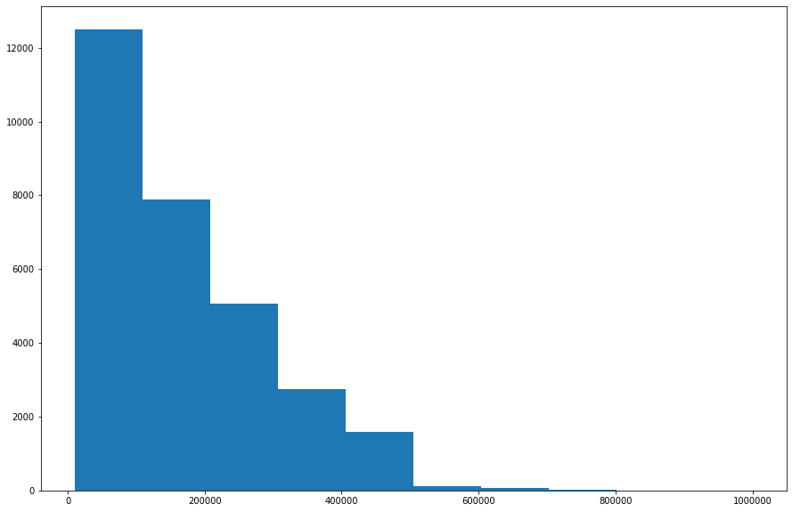

```python
plt.hist(creditDF['LIMIT_BAL'])
plt.show()
```

Como parte del ejercicio, se grafica un histograma modificando el número de 'bins' a 4:

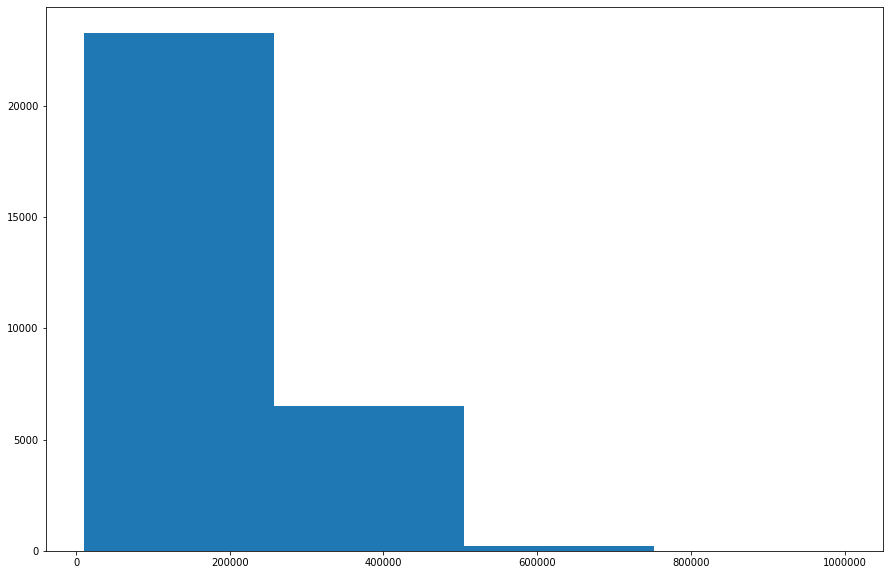

```python
plt.hist(creditDF['LIMIT_BAL'], bins=4)
plt.show()
```

#### Gráficos de línea

Los gráficos de líneas se usan a menudo en EDA para ilustrar el rando y el modo de cualquier variable numérica dada. Esto puede ser de utilidad para aspectos como evitar el sesgo y el sobreajuste del modelo e incluso identificar la colinealidad.

Se pueden crear gráficos de línea mediante matplotlib para una o múltiples variables (multivariable). En el ejemplo a contninuación se crea un gráfico de línea para la variable 'LIMIT_BAL' estudiada anteriormente.

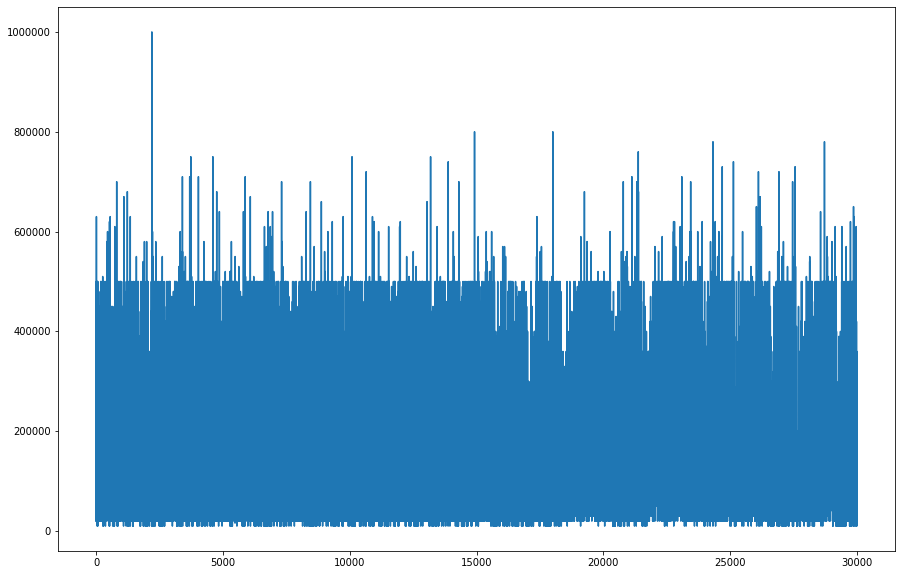

```python
plt.plot(creditDF['LIMIT_BAL'])
plt.show()
```

#### Gráficos de dispersión

Los diagramas de dispersión son muy útiles para comparar dos características o múltiples entre sí. Esto es muy útil para comprender las posibles relaciones entre los datos, pero no siempre apunta a alguna relación causal.

Para crear una comparación de dos características cualquiera, primero se debe establecer las dos características iguales a las variables de la siguiente manera:

```python
x = creditDF['PAY_0']
y = creditDF['PAY_2']
```

Posteriormente, se puede utilizar matplotlib para crear un diagrama de dispersión utilizando las dos variables creadas anteriormente 'x' y 'y':

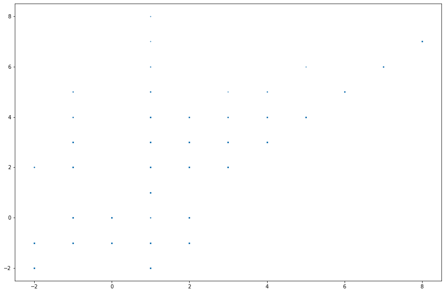

```python
plt.scatter(x,y,s=1)
plt.show()
```

#### Gráficos de caja

Los gráficos de caja son muy útiles para visualizar rápidamente dónde está la mayor parte de los datos en cualquier característica de función dada; además de permitir identificar fácilmente entidades con valores atípicos o variaciones extremas en las observaciones.

A continuación se muestran los componentes que pueden contener un diagrama de caja:

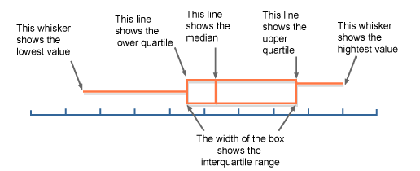

Las líneas que se extienden desde ambos lados del 'recuadro' en el centro del gráfico pueden demostrar la existencia de 'outlying data points' en el atributo si el punto va más allá de los extremos de las líneas (whiskers); sin embargo, esto no necesariamente indica que exista algún problema.

Mediante matplotlib, se pueden crear estos gráficos de la siguiente manera:

```python
header = creditDF.dtypes.index
print(header)
```

```
Index(['LIMIT_BAL', 'EDUCATION', 'MARRIAGE', 'AGE', 'PAY_0', 'PAY_2', 'PAY_3',
       'PAY_4', 'PAY_5', 'PAY_6', 'BILL_AMT1', 'BILL_AMT2', 'BILL_AMT3',
       'BILL_AMT4', 'BILL_AMT5', 'BILL_AMT6', 'PAY_AMT1', 'PAY_AMT2',
       'PAY_AMT3', 'PAY_AMT4', 'PAY_AMT5', 'PAY_AMT6',
       'default payment next month', 'LIMIT_BAL_DISCRETIZED',
       'AGE_DISCRETIZED'],
      dtype='object')
```

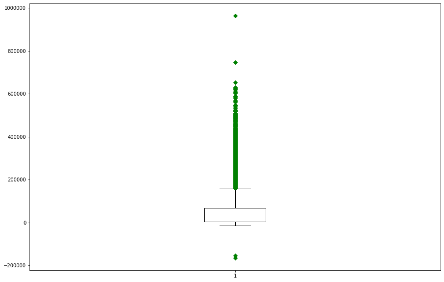

```python
A = creditDF['BILL_AMT1']
plt.boxplot(A,0,'gD')
plt.show()
```

A continuación, se muestra diferentes visualizaciones para poder comprender mejor los datos de Credit One y tratar de dar respuesta a las hipótesis antes planteadas. Para ello, se comienza analizando que porcentaje de personas se proyecta que no efectuará el pago del préstamo, con el fin de tener un panorama más claro de la situación planteada.

```python
countClientsBehavior = pd.Series(creditDF['default payment next month'].value_counts(dropna=False))
```

```python
labels = 'Will pay', 'Wouldn\'t pay'
sizes = [countClientsBehavior.iloc[0], countClientsBehavior[1]]
explode = (0, 0.1) # only 'explode' the 2nd slice (i.e. 'Wouldn't pay')
```

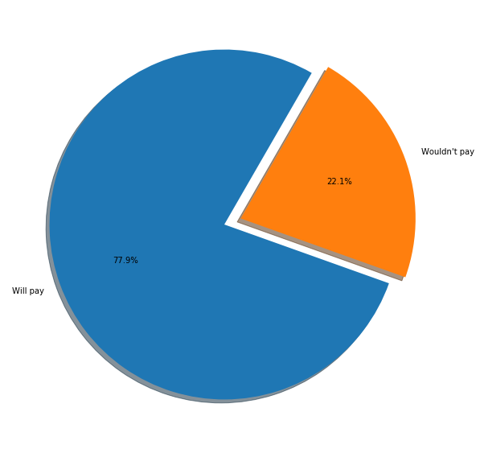

```python
plt.pie(sizes, explode=explode, labels=labels, autopct='%1.1f%%',
        shadow=True, startangle=60)
plt.show()
```

Del gráfico anterior, se puede observar que un alto porcentaje de los clientes (superior al 22%) se predice que no va a realizar el pago, evidenciando la gravedad del problema.

Ahora bien, con el fin de analizar si alguno de los atributos influye en la variable a predecir, se procede a separar la población en estudio entre clientes que realizan el pago y aquellos que no lo efectuan el siguiente mes. Para ello se crean dos subconjuntos de datos: creditDF_NDP, los cuales presentan un valor de variable 'default payment next month' igual a 0, y creditDF_DP con un valor de 'default payment next month' de 1.

```python
creditDF_NDP = creditDF[creditDF['default payment next month'] == 0]
```

```python
creditDF_NDP
```

|  | LIMIT_BAL | EDUCATION | MARRIAGE | AGE | PAY_0 | PAY_2 | PAY_3 | PAY_4 | PAY_5 | PAY_6 | ... | BILL_AMT6 | PAY_AMT1 | PAY_AMT2 | PAY_AMT3 | PAY_AMT4 | PAY_AMT5 | PAY_AMT6 | default payment next month | LIMIT_BAL_DISCRETIZED | AGE_DISCRETIZED |
| --- | --- | --- | --- | --- | --- | --- | --- | --- | --- | --- | --- | --- | --- | --- | --- | --- | --- | --- | --- | --- | --- |
| 2 | 90000 | university | single | 34 | 0 | 0 | 0 | 0 | 0 | 0 | ... | 15549 | 1518 | 1500 | 1000 | 1000 | 1000 | 5000 | 0 | Level_1 | Adults |
| 3 | 50000 | university | married | 37 | 0 | 0 | 0 | 0 | 0 | 0 | ... | 29547 | 2000 | 2019 | 1200 | 1100 | 1069 | 1000 | 0 | Level_1 | Adults |
| 4 | 50000 | university | married | 57 | -1 | 0 | -1 | 0 | 0 | 0 | ... | 19131 | 2000 | 36681 | 10000 | 9000 | 689 | 679 | 0 | Level_1 | Middle-aged adults |
| 5 | 50000 | graduate school | single | 37 | 0 | 0 | 0 | 0 | 0 | 0 | ... | 20024 | 2500 | 1815 | 657 | 1000 | 1000 | 800 | 0 | Level_1 | Adults |
| 6 | 500000 | graduate school | single | 29 | 0 | 0 | 0 | 0 | 0 | 0 | ... | 473944 | 55000 | 40000 | 38000 | 20239 | 13750 | 13770 | 0 | Level_5 | Young adults |
| ... | ... | ... | ... | ... | ... | ... | ... | ... | ... | ... | ... | ... | ... | ... | ... | ... | ... | ... | ... | ... | ... |
| 29990 | 140000 | university | married | 41 | 0 | 0 | 0 | 0 | 0 | 0 | ... | 46121 | 6000 | 7000 | 4228 | 1505 | 2000 | 2000 | 0 | Level_2 | Adults |
| 29992 | 10000 | high school | married | 43 | 0 | 0 | 0 | -2 | -2 | -2 | ... | 0 | 2000 | 0 | 0 | 0 | 0 | 0 | 0 | Level_1 | Adults |
| 29993 | 100000 | graduate school | single | 38 | 0 | -1 | -1 | 0 | 0 | 0 | ... | 55004 | 2000 | 111784 | 4000 | 3000 | 2000 | 2000 | 0 | Level_1 | Adults |
| 29995 | 220000 | high school | married | 39 | 0 | 0 | 0 | 0 | 0 | 0 | ... | 15980 | 8500 | 20000 | 5003 | 3047 | 5000 | 1000 | 0 | Level_3 | Adults |
| 29996 | 150000 | high school | single | 43 | -1 | -1 | -1 | -1 | 0 | 0 | ... | 0 | 1837 | 3526 | 8998 | 129 | 0 | 0 | 0 | Level_2 | Adults |

23364 rows × 25 columns

```python
creditDF_DP = creditDF[creditDF['default payment next month'] == 1]
```

```python
creditDF_DP
```

|  | LIMIT_BAL | EDUCATION | MARRIAGE | AGE | PAY_0 | PAY_2 | PAY_3 | PAY_4 | PAY_5 | PAY_6 | ... | BILL_AMT6 | PAY_AMT1 | PAY_AMT2 | PAY_AMT3 | PAY_AMT4 | PAY_AMT5 | PAY_AMT6 | default payment next month | LIMIT_BAL_DISCRETIZED | AGE_DISCRETIZED |
| --- | --- | --- | --- | --- | --- | --- | --- | --- | --- | --- | --- | --- | --- | --- | --- | --- | --- | --- | --- | --- | --- |
| 0 | 20000 | university | married | 24 | 2 | 2 | -1 | -1 | -2 | -2 | ... | 0 | 0 | 689 | 0 | 0 | 0 | 0 | 1 | Level_1 | Young adults |
| 1 | 120000 | university | single | 26 | -1 | 2 | 0 | 0 | 0 | 2 | ... | 3261 | 0 | 1000 | 1000 | 1000 | 0 | 2000 | 1 | Level_2 | Young adults |
| 13 | 70000 | university | single | 30 | 1 | 2 | 2 | 0 | 0 | 2 | ... | 36894 | 3200 | 0 | 3000 | 3000 | 1500 | 0 | 1 | Level_1 | Young adults |
| 16 | 20000 | graduate school | single | 24 | 0 | 0 | 2 | 2 | 2 | 2 | ... | 19104 | 3200 | 0 | 1500 | 0 | 1650 | 0 | 1 | Level_1 | Young adults |
| 21 | 120000 | university | married | 39 | -1 | -1 | -1 | -1 | -1 | -1 | ... | 316 | 316 | 316 | 0 | 632 | 316 | 0 | 1 | Level_2 | Adults |
| ... | ... | ... | ... | ... | ... | ... | ... | ... | ... | ... | ... | ... | ... | ... | ... | ... | ... | ... | ... | ... | ... |
| 29991 | 210000 | university | married | 34 | 3 | 2 | 2 | 2 | 2 | 2 | ... | 2500 | 0 | 0 | 0 | 0 | 0 | 0 | 1 | Level_3 | Adults |
| 29994 | 80000 | university | single | 34 | 2 | 2 | 2 | 2 | 2 | 2 | ... | 81158 | 7000 | 3500 | 0 | 7000 | 0 | 4000 | 1 | Level_1 | Adults |
| 29997 | 30000 | university | single | 37 | 4 | 3 | 2 | -1 | 0 | 0 | ... | 19357 | 0 | 0 | 22000 | 4200 | 2000 | 3100 | 1 | Level_1 | Adults |
| 29998 | 80000 | high school | married | 41 | 1 | -1 | 0 | 0 | 0 | -1 | ... | 48944 | 85900 | 3409 | 1178 | 1926 | 52964 | 1804 | 1 | Level_1 | Adults |
| 29999 | 50000 | university | married | 46 | 0 | 0 | 0 | 0 | 0 | 0 | ... | 15313 | 2078 | 1800 | 1430 | 1000 | 1000 | 1000 | 1 | Level_1 | Middle-aged adults |

6636 rows × 25 columns

Una de las hipótesis planteada está en función de la edad del cliente. En este caso se plantea que esta influye considerablemente en la determinación de si el cliente efectuará o no el pago del préstamo. Para ello se analiza, mediante un gráfico de caja, dónde se concentra la mayor cantidad de los datos para ambos subconjunto de datos.

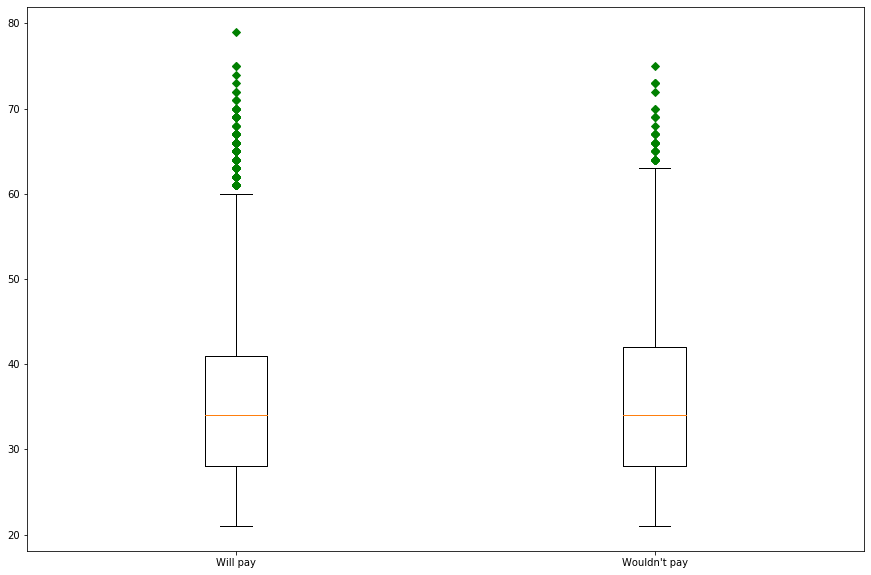

```python
B = [creditDF_NDP['AGE'], creditDF_DP['AGE']]
plt.boxplot(B,0,'gD', labels = labels)
plt.show()
```

En el gráfico anterior se puede observar que la concentración de datos en los dos subconjuntos es muy similar, entre los 30 y 40 años; por lo que no se obtiene una diferencia determinante entre ellos que permita concluir si el cliente efectuará el pago o no del préstamo. De este modo, se descarta la hipótesis que indica que la edad es un atributo determinante para predecir el pago o no del préstamo; y se puede, mediante el gráfico anterior, afirmar que los datos muestran un comportamiento contrario al planteado: **El pago o no del préstamo por parte del cliente no está determinado por la edad del mismo**.

Otra de las hipótesis que se planteó menciona que entre mayor sea el monto de crédito otorgado, el cliente tiende a incumplir más con el préstamo. Para ello se hace uso de un diagrama de dispersión, tal y como se muestra a continuación:

```python
import seaborn as sns
```

```python
sns.set(style="whitegrid")
```

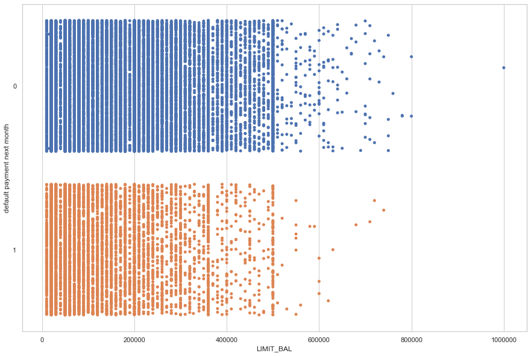

```python
sns.stripplot(x=creditDF['LIMIT_BAL'], y=creditDF['default payment next month'], jitter=0.4)
```

Del resultado anterior, se puede observar que la concentración de puntos en los límites de crédito inferiores a $200 000 es muy densa en ambos casos. Sin embargo; es observable que para clientes con un crédito superior a los 500 000 dólares, los casos de incumplimiento van en disminución. Esto no se puede determinar por medio del gráfico anterior ya que, como se menciona anteriormente, poco más del 22\% de los casos no efectúan el pago, por lo que la disminución en la concentración de puntos de un caso respecto a otro es esperado.

Para ello, se procede a realizar el análisis mediante un gráfico de barras, separando el límite de crédito con el que dispone el cliente en proporciones de 100 000 dólares y analizando el procentaje de clientes que se ubican únicamente en dicho intervalo para poder determinar cuál es la tendencia del comportamiento de los clientes respecto a este atributo.

Se procede a obtener los porcentajes de los clientes que se espera efectúen o no el pago del préstamo el siguiente mes mediante el atributo del límite de balance discretizado en la sección anterior.

```python
creditDF.groupby(by = "LIMIT_BAL_DISCRETIZED", observed = True)['default payment next month'].value_counts()
```

```
LIMIT_BAL_DISCRETIZED  default payment next month
Level_1                0                             8814
                       1                             3684
Level_2                0                             6345
                       1                             1535
Level_3                0                             4247
                       1                              812
Level_4                0                             2371
                       1                              388
Level_5                0                             1404
                       1                              194
Level_6                0                              110
                       1                               17
Level_7                0                               53
                       1                                3
Level_8                0                               19
                       1                                3
Level_10               0                                1
Name: default payment next month, dtype: int64
```

De lo anterior, se puede observar que no hay clientes a los cuales se les haya otorgado un crédito que se ubique dentro de la categoría 'Level_9' (800 000 - 900 000 dólares), lo que explica su ausencia en dicha salida. Con esto, se procede a realizar un gráfico de barras que permita determinar el comportamiento del cliente respecto al límite de crédito otorgado.

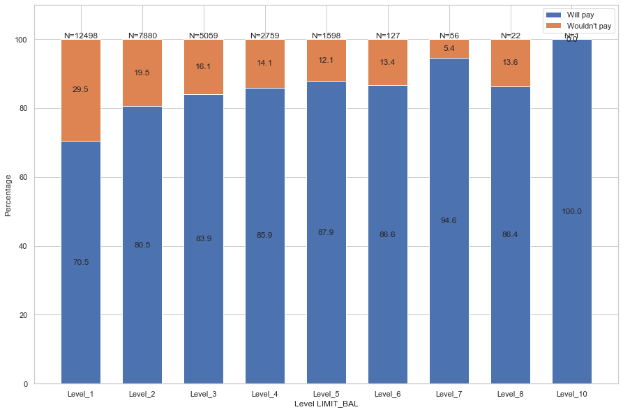

```python
x = ['Level_1', 'Level_2', 'Level_3', 'Level_4', 'Level_5', 'Level_6', 'Level_7', 'Level_8', 'Level_10']
width = 0.65  # the width of the bars
countNDP = creditDF_NDP['LIMIT_BAL_DISCRETIZED'].value_counts()
countDP = creditDF_DP['LIMIT_BAL_DISCRETIZED'].value_counts()
snum = creditDF['LIMIT_BAL_DISCRETIZED'].value_counts()



#normalization
countNDP_nor = (countNDP/snum)*100
countDP_nor = (countDP/snum)*100

countNDP_nor = countNDP_nor.dropna()
countDP_nor = countDP_nor.dropna()

p1 = plt.bar(x,countNDP_nor, width)
p2 = plt.bar(x,countDP_nor, width, bottom = countNDP_nor)

plt.ylabel('Percentage')
plt.xlabel('Level LIMIT_BAL')
plt.legend((p1[2], p2[0]), ('Will pay', 'Wouldn\'t pay'))

# add text annotation corresponding to the percentage of each data.
for xpos, ypos, yval in zip(x, countNDP_nor/2, countNDP_nor):
    plt.text(xpos, ypos, "%.1f"%yval, ha="center", va="center")
for xpos, ypos, yval in zip(x, countNDP_nor+countDP_nor/2, countDP_nor):
    plt.text(xpos, ypos, "%.1f"%yval, ha="center", va="center")
# add text annotation corresponding to the "total" value of each bar
for xpos, ypos, yval in zip(x, countNDP_nor+countDP_nor, snum):
    plt.text(xpos, ypos, "N=%d"%yval, ha="center", va="bottom")

plt.ylim(0,110)

plt.show()
```

Con el gráfico anterior, se puede observar que el porcentaje de clientes que incumplen con el pago del préstamo tiende a disminuir para aquellos clientes que se van ubicando en categorías que demuestran un mayor límite crédito. Se comienza con un 29.5% en la categoría de nivel 1, donde el máximo de crédito llega a los $100 000, el cual va disminuyendo el porcentaje de clientes que se proyecta incumplirán con los pagos hasta llegar a un máximo de un 14\% de clientes que incumplen con los pagos para categorías que superan los 500 000 dólares. Con esto, se puede concluir que ocurre lo contrario a la hipótesis antes planteada y, por lo cual, podemos confirmar que: **Entre menor sea el crédito otorgado al cliente, este tenderá a incumplir con los pagos del préstamo en un mayor porcentaje de los casos**.

Ahora bien, se procede a analizar otra de las hipótesis planteadas anteriormente, la cual indica que entre menor sea el grado de educación del cliente, mayor tiende a incumplir con el pago del préstamo.

```python
countEduc_NDP = pd.Series(creditDF_NDP['EDUCATION'].value_counts(dropna=False))
countEduc_DP = pd.Series(creditDF_DP['EDUCATION'].value_counts(dropna=False))
creditDF.groupby(by = "EDUCATION", observed = True)['default payment next month'].value_counts()
```

```
EDUCATION        default payment next month
university       0                             10700
                 1                              3330
graduate school  0                              8549
                 1                              2036
high school      0                              3680
                 1                              1237
others           0                               435
                 1                                33
Name: default payment next month, dtype: int64
```

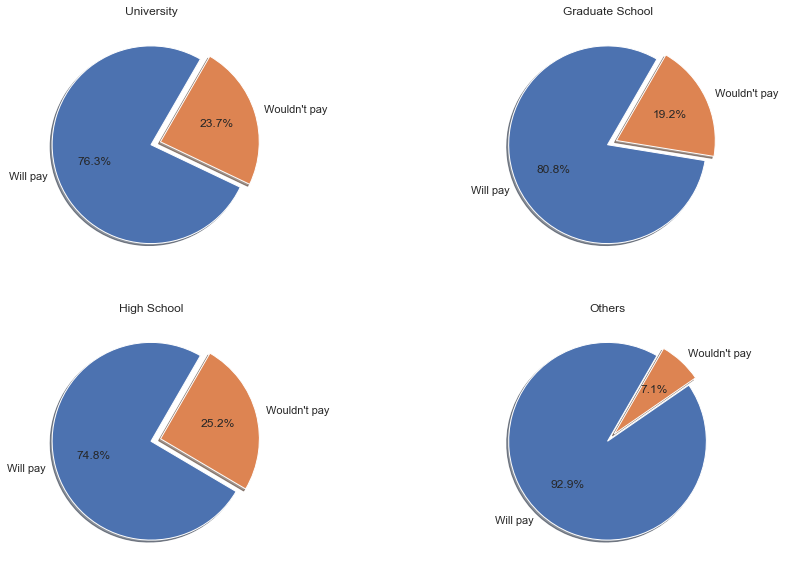

```python
labels = 'Will pay', 'Wouldn\'t pay'
sizesUniversity = [countEduc_NDP.loc['university'], countEduc_DP.loc['university']]
sizesGraduateSchool = [countEduc_NDP.loc['graduate school'], countEduc_DP.loc['graduate school']]
sizesHighSchool = [countEduc_NDP.loc['high school'], countEduc_DP.loc['high school']]
sizesOthers = [countEduc_NDP.loc['others'], countEduc_DP.loc['others']]
explode = (0, 0.1) # only 'explode' the 2nd slice (i.e. 'Wouldn't pay')

# Make figure and axes
fig, axs = plt.subplots(2,2)

# Pie plots

axs[0, 0].pie(sizesUniversity, explode=explode, labels=labels, autopct='%1.1f%%',
        shadow=True, startangle=60)
axs[0, 0].set_title("University")
axs[0, 1].pie(sizesGraduateSchool, explode=explode, labels=labels, autopct='%1.1f%%',
        shadow=True, startangle=60)
axs[0, 1].set_title("Graduate School")
axs[1, 0].pie(sizesHighSchool, explode=explode, labels=labels, autopct='%1.1f%%',
        shadow=True, startangle=60)
axs[1, 0].set_title("High School")
axs[1, 1].pie(sizesOthers, explode=explode, labels=labels, autopct='%1.1f%%',
        shadow=True, startangle=60)
axs[1, 1].set_title("Others")
```

A continuación, se analiza la influencia de otros atributos que, si bien no se plantearon hipótesis respecto a estos, pueden considerarse relevantes en el estudio. Se comienza con el análisis del atributo que representa el estado civil del cliente.

```python
creditDF.groupby(by = "MARRIAGE", observed = True)['default payment next month'].value_counts()
```

```
MARRIAGE  default payment next month
married   0                             10453
          1                              3206
single    0                             12623
          1                              3341
divorce   0                               239
          1                                84
others    0                                49
          1                                 5
Name: default payment next month, dtype: int64
```

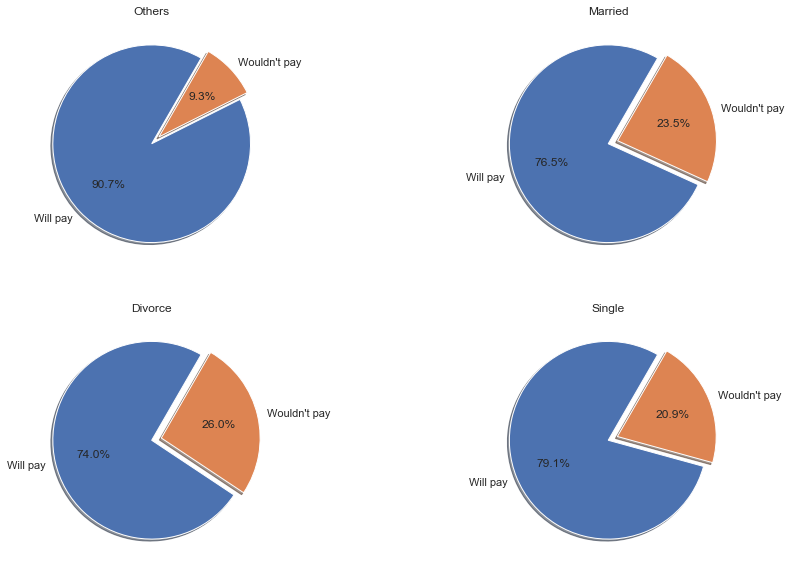

```python
countMarr_NDP = pd.Series(creditDF_NDP['MARRIAGE'].value_counts(dropna=False))
countMarr_DP = pd.Series(creditDF_DP['MARRIAGE'].value_counts(dropna=False))

labels = 'Will pay', 'Wouldn\'t pay'
countSingle = [countMarr_NDP.loc['single'], countMarr_DP.loc['single']]
countMarried = [countMarr_NDP.loc['married'], countMarr_DP.loc['married']]
countDivorce = [countMarr_NDP.loc['divorce'], countMarr_DP.loc['divorce']]
countOthers = [countMarr_NDP.loc['others'], countMarr_DP.loc['others']]
explode = (0, 0.1) # only 'explode' the 2nd slice (i.e. 'Default')

# Make figure and axes
fig, axs = plt.subplots(2,2)

# Pie plots

axs[1, 1].pie(countSingle, explode=explode, labels=labels, autopct='%1.1f%%',
        shadow=True, startangle=60)
axs[1, 1].set_title("Single")
axs[0, 1].pie(countMarried, explode=explode, labels=labels, autopct='%1.1f%%',
        shadow=True, startangle=60)
axs[0, 1].set_title("Married")
axs[1, 0].pie(countDivorce, explode=explode, labels=labels, autopct='%1.1f%%',
        shadow=True, startangle=60)
axs[1, 0].set_title("Divorce")
axs[0, 0].pie(countOthers, explode=explode, labels=labels, autopct='%1.1f%%',
        shadow=True, startangle=60)
axs[0, 0].set_title("Others")
```

De lo anterior se puede resaltar que la gran mayoría de los clientes se encuentran dentro de las categorías 'married' y 'single', menos de 400 clientes se encuentran en las dos categorías restantes. Analizando los dos grupos más representativos, los porcentajes que reflejan el incumplimiento en los pagos son muy similares, 23.5% para aquellos clientes cuyo estado civil corresponde a casado(a) y un 20.9% para los clientes identificados como soltero(a). Hay un ligero aumento en el porcentaje que refleja el incumplimiento de los pagos en el caso de aquellos clientes cuyo estado civil corresponde a 'divorce', alcanzando un 26%. Se refleja un bajo porcentaje en la categoría 'others', 9.3%; sin embargo, la cantidad de clientes en esta categoría son pocos, por lo que sería bueno llevar a cabo el análisis con una muestra mayor dentor de esta categoría.

Finalmente, se analiza el historial crediticio de los clientes considerando la cantidad de meses en el que se facturó algún monto y el cliente no realizó ningún pago. Esto se determino sumando la cantidad de meses en el que el pago por parte del cliente fue igual a 0 dólares y restando la cantidad de meses en el que se le factura al cliente un monto de 0 dólares. A continuación se muestran los resultados:

```python
countZeroBill_DP = (creditDF_DP[['BILL_AMT1','BILL_AMT2','BILL_AMT3','BILL_AMT4','BILL_AMT5','BILL_AMT6',]] == 0).astype(int).sum(axis=1)
countZeroPay_DP = (creditDF_DP[['PAY_AMT1','PAY_AMT2','PAY_AMT3','PAY_AMT4','PAY_AMT5','PAY_AMT6',]] == 0).astype(int).sum(axis=1)
countZeroTotal_DP = countZeroPay_DP - countZeroBill_DP
countZeroBill_NDP = (creditDF_NDP[['BILL_AMT1','BILL_AMT2','BILL_AMT3','BILL_AMT4','BILL_AMT5','BILL_AMT6',]] == 0).astype(int).sum(axis=1)
countZeroPay_NDP = (creditDF_NDP[['PAY_AMT1','PAY_AMT2','PAY_AMT3','PAY_AMT4','PAY_AMT5','PAY_AMT6',]] == 0).astype(int).sum(axis=1)
countZeroTotal_NDP = countZeroPay_NDP - countZeroBill_NDP
```

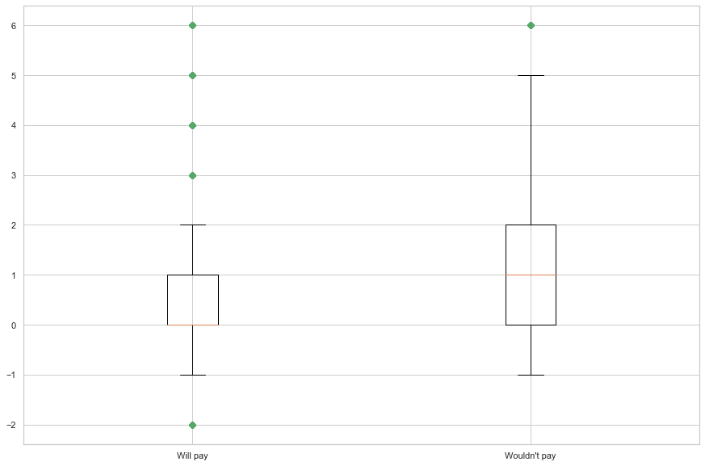

```python
C = [countZeroTotal_NDP, countZeroTotal_DP]
plt.boxplot(C,0,'gD', labels = labels)
plt.show()
```

De lo anterior se puede destacar que para el caso en el que se predice que el cliente efectuará el pago el siguiente mes se puede observar que se tiene una mediana de 0; es decir, el historial crediticio de los 6 meses en análisis refleja que no hubo algún mes en el que se haya facturado y no se haya reportado ningún pago por parte del cliente. En este caso, la mayor concentración de datos oscilan entre los valores de 0 o 1; además, escazas observaciones se encuentran por encima de 2 meses en el que se haya identificado el comportamiento en análisis.

Por otro lado, para el caso en el que se predice no se efectuará el pago el siguiente mes, la mediana es de 1 y la mayor concentración de datos de datos corresponden a valores de 0, 1 y 2. Además, se refleja una mayor concentración de datos que van de 2 hasta 5 con respecto a los casos en el que se predice se efectuará el pago.

### Correlación

Por medio de la librería Pandas se puede construir una matríz de coeficiente de correlación de la siguiente manera:

```python
# Drop columns that don't have relevance to the analysis
credit = credit.drop(columns=['ID', 'SEX'])
```

```python
corrMat = credit.corr()
corrMat
```

|  | LIMIT_BAL | EDUCATION | MARRIAGE | AGE | PAY_0 | PAY_2 | PAY_3 | PAY_4 | PAY_5 | PAY_6 | ... | BILL_AMT4 | BILL_AMT5 | BILL_AMT6 | PAY_AMT1 | PAY_AMT2 | PAY_AMT3 | PAY_AMT4 | PAY_AMT5 | PAY_AMT6 | default payment next month |
| --- | --- | --- | --- | --- | --- | --- | --- | --- | --- | --- | --- | --- | --- | --- | --- | --- | --- | --- | --- | --- | --- |
| LIMIT_BAL | 1.000000 | -0.219161 | -0.108139 | 0.144713 | -0.271214 | -0.296382 | -0.286123 | -0.267460 | -0.249411 | -0.235195 | ... | 0.293988 | 0.295562 | 0.290389 | 0.195236 | 0.178408 | 0.210167 | 0.203242 | 0.217202 | 0.219595 | -0.153520 |
| EDUCATION | -0.219161 | 1.000000 | -0.143464 | 0.175061 | 0.105364 | 0.121566 | 0.114025 | 0.108793 | 0.097520 | 0.082316 | ... | -0.000451 | -0.007567 | -0.009099 | -0.037456 | -0.030038 | -0.039943 | -0.038218 | -0.040358 | -0.037200 | 0.028006 |
| MARRIAGE | -0.108139 | -0.143464 | 1.000000 | -0.414170 | 0.019917 | 0.024199 | 0.032688 | 0.033122 | 0.035629 | 0.034345 | ... | -0.023344 | -0.025393 | -0.021207 | -0.005979 | -0.008093 | -0.003541 | -0.012659 | -0.001205 | -0.006641 | -0.024339 |
| AGE | 0.144713 | 0.175061 | -0.414170 | 1.000000 | -0.039447 | -0.050148 | -0.053048 | -0.049722 | -0.053826 | -0.048773 | ... | 0.051353 | 0.049345 | 0.047613 | 0.026147 | 0.021785 | 0.029247 | 0.021379 | 0.022850 | 0.019478 | 0.013890 |
| PAY_0 | -0.271214 | 0.105364 | 0.019917 | -0.039447 | 1.000000 | 0.672164 | 0.574245 | 0.538841 | 0.509426 | 0.474553 | ... | 0.179125 | 0.180635 | 0.176980 | -0.079269 | -0.070101 | -0.070561 | -0.064005 | -0.058190 | -0.058673 | 0.324794 |
| PAY_2 | -0.296382 | 0.121566 | 0.024199 | -0.050148 | 0.672164 | 1.000000 | 0.766552 | 0.662067 | 0.622780 | 0.575501 | ... | 0.222237 | 0.221348 | 0.219403 | -0.080701 | -0.058990 | -0.055901 | -0.046858 | -0.037093 | -0.036500 | 0.263551 |
| PAY_3 | -0.286123 | 0.114025 | 0.032688 | -0.053048 | 0.574245 | 0.766552 | 1.000000 | 0.777359 | 0.686775 | 0.632684 | ... | 0.227202 | 0.225145 | 0.222327 | 0.001295 | -0.066793 | -0.053311 | -0.046067 | -0.035863 | -0.035861 | 0.235253 |
| PAY_4 | -0.267460 | 0.108793 | 0.033122 | -0.049722 | 0.538841 | 0.662067 | 0.777359 | 1.000000 | 0.819835 | 0.716449 | ... | 0.245917 | 0.242902 | 0.239154 | -0.009362 | -0.001944 | -0.069235 | -0.043461 | -0.033590 | -0.026565 | 0.216614 |
| PAY_5 | -0.249411 | 0.097520 | 0.035629 | -0.053826 | 0.509426 | 0.622780 | 0.686775 | 0.819835 | 1.000000 | 0.816900 | ... | 0.271915 | 0.269783 | 0.262509 | -0.006089 | -0.003191 | 0.009062 | -0.058299 | -0.033337 | -0.023027 | 0.204149 |
| PAY_6 | -0.235195 | 0.082316 | 0.034345 | -0.048773 | 0.474553 | 0.575501 | 0.632684 | 0.716449 | 0.816900 | 1.000000 | ... | 0.266356 | 0.290894 | 0.285091 | -0.001496 | -0.005223 | 0.005834 | 0.019018 | -0.046434 | -0.025299 | 0.186866 |
| BILL_AMT1 | 0.285430 | 0.023581 | -0.023472 | 0.056239 | 0.187068 | 0.234887 | 0.208473 | 0.202812 | 0.206684 | 0.207373 | ... | 0.860272 | 0.829779 | 0.802650 | 0.140277 | 0.099355 | 0.156887 | 0.158303 | 0.167026 | 0.179341 | -0.019644 |
| BILL_AMT2 | 0.278314 | 0.018749 | -0.021602 | 0.054283 | 0.189859 | 0.235257 | 0.237295 | 0.225816 | 0.226913 | 0.226924 | ... | 0.892482 | 0.859778 | 0.831594 | 0.280365 | 0.100851 | 0.150718 | 0.147398 | 0.157957 | 0.174256 | -0.014193 |
| BILL_AMT3 | 0.283236 | 0.013002 | -0.024909 | 0.053710 | 0.179785 | 0.224146 | 0.227494 | 0.244983 | 0.243335 | 0.241181 | ... | 0.923969 | 0.883910 | 0.853320 | 0.244335 | 0.316936 | 0.130011 | 0.143405 | 0.179712 | 0.182326 | -0.014076 |
| BILL_AMT4 | 0.293988 | -0.000451 | -0.023344 | 0.051353 | 0.179125 | 0.222237 | 0.227202 | 0.245917 | 0.271915 | 0.266356 | ... | 1.000000 | 0.940134 | 0.900941 | 0.233012 | 0.207564 | 0.300023 | 0.130191 | 0.160433 | 0.177637 | -0.010156 |
| BILL_AMT5 | 0.295562 | -0.007567 | -0.025393 | 0.049345 | 0.180635 | 0.221348 | 0.225145 | 0.242902 | 0.269783 | 0.290894 | ... | 0.940134 | 1.000000 | 0.946197 | 0.217031 | 0.181246 | 0.252305 | 0.293118 | 0.141574 | 0.164184 | -0.006760 |
| BILL_AMT6 | 0.290389 | -0.009099 | -0.021207 | 0.047613 | 0.176980 | 0.219403 | 0.222327 | 0.239154 | 0.262509 | 0.285091 | ... | 0.900941 | 0.946197 | 1.000000 | 0.199965 | 0.172663 | 0.233770 | 0.250237 | 0.307729 | 0.115494 | -0.005372 |
| PAY_AMT1 | 0.195236 | -0.037456 | -0.005979 | 0.026147 | -0.079269 | -0.080701 | 0.001295 | -0.009362 | -0.006089 | -0.001496 | ... | 0.233012 | 0.217031 | 0.199965 | 1.000000 | 0.285576 | 0.252191 | 0.199558 | 0.148459 | 0.185735 | -0.072929 |
| PAY_AMT2 | 0.178408 | -0.030038 | -0.008093 | 0.021785 | -0.070101 | -0.058990 | -0.066793 | -0.001944 | -0.003191 | -0.005223 | ... | 0.207564 | 0.181246 | 0.172663 | 0.285576 | 1.000000 | 0.244770 | 0.180107 | 0.180908 | 0.157634 | -0.058579 |
| PAY_AMT3 | 0.210167 | -0.039943 | -0.003541 | 0.029247 | -0.070561 | -0.055901 | -0.053311 | -0.069235 | 0.009062 | 0.005834 | ... | 0.300023 | 0.252305 | 0.233770 | 0.252191 | 0.244770 | 1.000000 | 0.216325 | 0.159214 | 0.162740 | -0.056250 |
| PAY_AMT4 | 0.203242 | -0.038218 | -0.012659 | 0.021379 | -0.064005 | -0.046858 | -0.046067 | -0.043461 | -0.058299 | 0.019018 | ... | 0.130191 | 0.293118 | 0.250237 | 0.199558 | 0.180107 | 0.216325 | 1.000000 | 0.151830 | 0.157834 | -0.056827 |
| PAY_AMT5 | 0.217202 | -0.040358 | -0.001205 | 0.022850 | -0.058190 | -0.037093 | -0.035863 | -0.033590 | -0.033337 | -0.046434 | ... | 0.160433 | 0.141574 | 0.307729 | 0.148459 | 0.180908 | 0.159214 | 0.151830 | 1.000000 | 0.154896 | -0.055124 |
| PAY_AMT6 | 0.219595 | -0.037200 | -0.006641 | 0.019478 | -0.058673 | -0.036500 | -0.035861 | -0.026565 | -0.023027 | -0.025299 | ... | 0.177637 | 0.164184 | 0.115494 | 0.185735 | 0.157634 | 0.162740 | 0.157834 | 0.154896 | 1.000000 | -0.053183 |
| default payment next month | -0.153520 | 0.028006 | -0.024339 | 0.013890 | 0.324794 | 0.263551 | 0.235253 | 0.216614 | 0.204149 | 0.186866 | ... | -0.010156 | -0.006760 | -0.005372 | -0.072929 | -0.058579 | -0.056250 | -0.056827 | -0.055124 | -0.053183 | 1.000000 |

23 rows × 23 columns

Obteniendo el mapa de calor de la respectiva matríz de correlación:

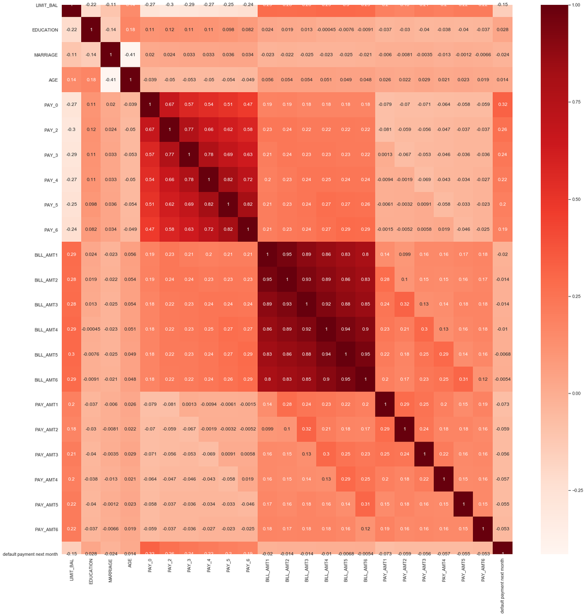

```python
plt.figure(figsize=(25,25))
sns.heatmap(corrMat, annot=True, cmap=plt.cm.Reds)
plt.show()
```

Se procede a resaltar aquellas variables dependientes que tienen una mayor correlación con la variable 'default payment next month':

```python
cor_target = abs(corrMat['default payment next month'])

#Selecting highly correlated features
relevant_features = cor_target[cor_target>0.1]
relevant_features
```

```
LIMIT_BAL                     0.153520
PAY_0                         0.324794
PAY_2                         0.263551
PAY_3                         0.235253
PAY_4                         0.216614
PAY_5                         0.204149
PAY_6                         0.186866
default payment next month    1.000000
Name: default payment next month, dtype: float64
```

De lo anterior se puede confirmar que ninguna de las variables independientes en estudio tienen una alta correlación con la variable dependiente, 'default payment next month' en este caso.

### Covarianza

La covarianza se utiliza para medir el grado lineal de cambio entre dos variables. En pocas palabras, puede usar la covarianza para medir cómo los cambios en una variable están asociados con los cambios en una segunda variable. Esto será muy importante al estudiar el impacto que pueden tener varias características en las tasas predeterminadas. El cálculo de la covarianza se hace de la siguiente manera:

```python
covMat = credit.cov()
covMat
```

|  | LIMIT_BAL | EDUCATION | MARRIAGE | AGE | PAY_0 | PAY_2 | PAY_3 | PAY_4 | PAY_5 | PAY_6 | ... | BILL_AMT4 | BILL_AMT5 | BILL_AMT6 | PAY_AMT1 | PAY_AMT2 | PAY_AMT3 | PAY_AMT4 | PAY_AMT5 | PAY_AMT6 | default payment next month |
| --- | --- | --- | --- | --- | --- | --- | --- | --- | --- | --- | --- | --- | --- | --- | --- | --- | --- | --- | --- | --- | --- |
| LIMIT_BAL | 1.683446e+10 | -22474.028945 | -7323.669658 | 173076.722569 | -39545.930009 | -46037.648360 | -44432.253315 | -40571.811859 | -36670.562325 | -35093.083441 | ... | 2.453926e+09 | 2.331481e+09 | 2.243837e+09 | 4.195711e+08 | 5.333504e+08 | 4.801180e+08 | 4.131202e+08 | 4.305657e+08 | 5.065153e+08 | -8267.551759 |
| EDUCATION | -2.247403e+04 | 0.624651 | -0.059184 | 1.275380 | 0.093584 | 0.115025 | 0.107861 | 0.100528 | 0.087340 | 0.074816 | ... | -2.294883e+01 | -3.635777e+02 | -4.282742e+02 | -4.903302e+02 | -5.470050e+02 | -5.558343e+02 | -4.732070e+02 | -4.873359e+02 | -5.226734e+02 | 0.009187 |
| MARRIAGE | -7.323670e+03 | -0.059184 | 0.272452 | -1.992764 | 0.011683 | 0.015122 | 0.020421 | 0.020213 | 0.021074 | 0.020616 | ... | -7.838816e+02 | -8.058409e+02 | -6.592233e+02 | -5.169161e+01 | -9.732797e+01 | -3.254608e+01 | -1.035182e+02 | -9.607709e+00 | -6.162327e+01 | -0.005273 |
| AGE | 1.730767e+05 | 1.275380 | -1.992764 | 84.969755 | -0.408639 | -0.553408 | -0.585263 | -0.535851 | -0.562245 | -0.517022 | ... | 3.045311e+04 | 2.765407e+04 | 2.613765e+04 | 3.992042e+03 | 4.626862e+03 | 4.746824e+03 | 3.087324e+03 | 3.218052e+03 | 3.191904e+03 | 0.053143 |
| PAY_0 | -3.954593e+04 | 0.093584 | 0.011683 | -0.408639 | 1.262930 | 0.904330 | 0.772384 | 0.707972 | 0.648743 | 0.613292 | ... | 1.295025e+04 | 1.234167e+04 | 1.184476e+04 | -1.475495e+03 | -1.815138e+03 | -1.396168e+03 | -1.126848e+03 | -9.991077e+02 | -1.172194e+03 | 0.151499 |
| PAY_2 | -4.603765e+04 | 0.115025 | 0.015122 | -0.553408 | 0.904330 | 1.433254 | 1.098371 | 0.926680 | 0.844886 | 0.792320 | ... | 1.711630e+04 | 1.611095e+04 | 1.564288e+04 | -1.600241e+03 | -1.627192e+03 | -1.178331e+03 | -8.788439e+02 | -6.784685e+02 | -7.768350e+02 | 0.130960 |
| PAY_3 | -4.443225e+04 | 0.107861 | 0.020421 | -0.585263 | 0.772384 | 1.098371 | 1.432492 | 1.087761 | 0.931455 | 0.870815 | ... | 1.749410e+04 | 1.638295e+04 | 1.584709e+04 | 2.566847e+01 | -1.841953e+03 | -1.123429e+03 | -8.637622e+02 | -6.557960e+02 | -7.630260e+02 | 0.116867 |
| PAY_4 | -4.057181e+04 | 0.100528 | 0.020213 | -0.535851 | 0.707972 | 0.926680 | 1.087761 | 1.366885 | 1.086161 | 0.963263 | ... | 1.849642e+04 | 1.726555e+04 | 1.665159e+04 | -1.812956e+02 | -5.235817e+01 | -1.425205e+03 | -7.960357e+02 | -5.999916e+02 | -5.521373e+02 | 0.105115 |
| PAY_5 | -3.667056e+04 | 0.087340 | 0.021074 | -0.562245 | 0.648743 | 0.844886 | 0.931455 | 1.086161 | 1.284114 | 1.064545 | ... | 1.982293e+04 | 1.858659e+04 | 1.771569e+04 | -1.142817e+02 | -8.332449e+01 | 1.808121e+02 | -1.034962e+03 | -5.771610e+02 | -4.638926e+02 | 0.096020 |
| PAY_6 | -3.509308e+04 | 0.074816 | 0.020616 | -0.517022 | 0.613292 | 0.792320 | 0.870815 | 0.963263 | 1.064545 | 1.322472 | ... | 1.970555e+04 | 2.033812e+04 | 1.952488e+04 | -2.850067e+01 | -1.383995e+02 | 1.181210e+02 | 3.426237e+02 | -8.158327e+02 | -5.172163e+02 | 0.089194 |
| BILL_AMT1 | 2.727020e+09 | 1372.377644 | -902.154685 | 38172.933546 | 15480.304170 | 20706.614217 | 18373.210469 | 17460.198259 | 17246.377531 | 17560.424872 | ... | 4.075286e+09 | 3.714795e+09 | 3.519876e+09 | 1.710894e+08 | 1.685692e+08 | 2.034048e+08 | 1.826164e+08 | 1.879091e+08 | 2.347681e+08 | -600.394108 |
| BILL_AMT2 | 2.570130e+09 | 1054.657595 | -802.517866 | 35613.657962 | 15185.916919 | 20045.829482 | 20214.071495 | 18790.627741 | 18301.285286 | 18573.527165 | ... | 4.086508e+09 | 3.720401e+09 | 3.524868e+09 | 3.305146e+08 | 1.653859e+08 | 1.888731e+08 | 1.643518e+08 | 1.717652e+08 | 2.204845e+08 | -419.289137 |
| BILL_AMT3 | 2.548533e+09 | 712.664124 | -901.679085 | 34334.251320 | 14011.556537 | 18609.510991 | 18882.491544 | 19862.999426 | 19122.663330 | 19234.422476 | ... | 4.122238e+09 | 3.726780e+09 | 3.524247e+09 | 2.806565e+08 | 5.064226e+08 | 1.587478e+08 | 1.558003e+08 | 1.904126e+08 | 2.247817e+08 | -405.153680 |
| BILL_AMT4 | 2.453926e+09 | -22.948827 | -783.881599 | 30453.108180 | 12950.248389 | 17116.298983 | 17494.100555 | 18496.423186 | 19822.925512 | 19705.551629 | ... | 4.138716e+09 | 3.677105e+09 | 3.451762e+09 | 2.482888e+08 | 3.076686e+08 | 3.398374e+08 | 1.312133e+08 | 1.576892e+08 | 2.031590e+08 | -271.199885 |
| BILL_AMT5 | 2.331481e+09 | -363.577664 | -805.840875 | 27654.067800 | 12341.668685 | 16110.952468 | 16382.947539 | 17265.551898 | 18586.590324 | 20338.120325 | ... | 3.677105e+09 | 3.696294e+09 | 3.425914e+09 | 2.185501e+08 | 2.538936e+08 | 2.700805e+08 | 2.791830e+08 | 1.315051e+08 | 1.774537e+08 | -170.597447 |
| BILL_AMT6 | 2.243837e+09 | -428.274232 | -659.223347 | 26137.648547 | 11844.759724 | 15642.875812 | 15847.089648 | 16651.586314 | 17715.690075 | 19524.880348 | ... | 3.451762e+09 | 3.425914e+09 | 3.546692e+09 | 1.972478e+08 | 2.369244e+08 | 2.451233e+08 | 2.334670e+08 | 2.799982e+08 | 1.222761e+08 | -132.796294 |
| PAY_AMT1 | 4.195711e+08 | -490.330155 | -51.691615 | 3992.041735 | -1475.495089 | -1600.240756 | 25.668468 | -181.295613 | -114.281714 | -28.500666 | ... | 2.482888e+08 | 2.185501e+08 | 1.972478e+08 | 2.743423e+08 | 1.089849e+08 | 7.354626e+07 | 5.178189e+07 | 3.756893e+07 | 5.469033e+07 | -501.374552 |
| PAY_AMT2 | 5.333504e+08 | -547.005021 | -97.327974 | 4626.861549 | -1815.138407 | -1627.192336 | -1841.952825 | -52.358166 | -83.324487 | -138.399452 | ... | 3.076686e+08 | 2.538936e+08 | 2.369244e+08 | 1.089849e+08 | 5.308817e+08 | 9.929841e+07 | 6.501168e+07 | 6.368414e+07 | 6.456816e+07 | -560.210740 |
| PAY_AMT3 | 4.801180e+08 | -555.834305 | -32.546082 | 4746.824393 | -1396.168258 | -1178.331282 | -1123.428782 | -1425.205189 | 180.812142 | 118.121022 | ... | 3.398374e+08 | 2.700805e+08 | 2.451233e+08 | 7.354626e+07 | 9.929841e+07 | 3.100051e+08 | 5.966970e+07 | 4.282921e+07 | 5.093879e+07 | -411.076284 |
| PAY_AMT4 | 4.131202e+08 | -473.206951 | -103.518204 | 3087.324192 | -1126.847945 | -878.843879 | -863.762183 | -796.035739 | -1034.961970 | 342.623730 | ... | 1.312133e+08 | 2.791830e+08 | 2.334670e+08 | 5.178189e+07 | 6.501168e+07 | 5.966970e+07 | 2.454286e+08 | 3.634098e+07 | 4.395747e+07 | -369.515887 |
| PAY_AMT5 | 4.305657e+08 | -487.335947 | -9.607709 | 3218.052172 | -999.107730 | -678.468530 | -655.796002 | -599.991629 | -577.161017 | -815.832688 | ... | 1.576892e+08 | 1.315051e+08 | 2.799982e+08 | 3.756893e+07 | 6.368414e+07 | 4.282921e+07 | 3.634098e+07 | 2.334266e+08 | 4.207110e+07 | -349.562530 |
| PAY_AMT6 | 5.065153e+08 | -522.673379 | -61.623271 | 3191.903901 | -1172.193614 | -776.835035 | -763.026041 | -552.137338 | -463.892613 | -517.216277 | ... | 2.031590e+08 | 1.774537e+08 | 1.222761e+08 | 5.469033e+07 | 6.456816e+07 | 5.093879e+07 | 4.395747e+07 | 4.207110e+07 | 3.160383e+08 | -392.426415 |
| default payment next month | -8.267552e+03 | 0.009187 | -0.005273 | 0.053143 | 0.151499 | 0.130960 | 0.116867 | 0.105115 | 0.096020 | 0.089194 | ... | -2.711999e+02 | -1.705974e+02 | -1.327963e+02 | -5.013746e+02 | -5.602107e+02 | -4.110763e+02 | -3.695159e+02 | -3.495625e+02 | -3.924264e+02 | 0.172276 |

23 rows × 23 columns

```python
cov_target = covMat['default payment next month']

relevant_features = cov_target[cov_target>0]
relevant_features
```

```
EDUCATION                     0.009187
AGE                           0.053143
PAY_0                         0.151499
PAY_2                         0.130960
PAY_3                         0.116867
PAY_4                         0.105115
PAY_5                         0.096020
PAY_6                         0.089194
default payment next month    0.172276
Name: default payment next month, dtype: float64
```

```python
relevant_features = cov_target[cov_target<0]
relevant_features
```

```
LIMIT_BAL   -8267.551759
MARRIAGE       -0.005273
BILL_AMT1    -600.394108
BILL_AMT2    -419.289137
BILL_AMT3    -405.153680
BILL_AMT4    -271.199885
BILL_AMT5    -170.597447
BILL_AMT6    -132.796294
PAY_AMT1     -501.374552
PAY_AMT2     -560.210740
PAY_AMT3     -411.076284
PAY_AMT4     -369.515887
PAY_AMT5     -349.562530
PAY_AMT6     -392.426415
Name: default payment next month, dtype: float64
```

Con respecto a la variable dependiente, no existe una relación directa clara con las demás variables independientes ya que los resultados positivos son muy cercanos a 0. Por el contrario, si existe relación indirecta con los atributos de 'LIMIT_BAL' y los atributos que indican los montos de facturas y pagos.